# Table manipulation

Authors

Affiliations

dr.sc. Paula Štancl

Bioinformatics group, Faculty of Science

dr.sc. Andrea Gelemanović

MedILS, UNIST

# Tables (`data.frame` vs `data.table`)

A **`data.frame`** is a 2D table-like structure where columns can hold different data types. **`data.table`** is an enhanced version of **`data.frame`** that provides faster and more memory-efficient operations.

**Built-in datasets**

- R comes with several **built-in datasets** that are useful for learning, testing, and demonstrating functions without needing to load external data.
- These datasets are included in base R and standard packages like `datasets`, and can be accessed directly by name (e.g., **`CO2`**, **`iris`**, **`mtcars`**, etc.).

We will be working with build-in dataset **iris** introduced by Ronald Fisher in his 1936 paper *The use of multiple measurements in taxonomic problems*, contains three plant species (setosa, virginica, versicolor) and four features measured for each sample.

Let’s examine the first six rows of the table!

```r
# Call the table
head(iris)
```

|  | Sepal.Length | Sepal.Width | Petal.Length | Petal.Width | Species |
| --- | --- | --- | --- | --- | --- |
| 1 | 5.1 | 3.5 | 1.4 | 0.2 | setosa |
| 2 | 4.9 | 3.0 | 1.4 | 0.2 | setosa |
| 3 | 4.7 | 3.2 | 1.3 | 0.2 | setosa |
| 4 | 4.6 | 3.1 | 1.5 | 0.2 | setosa |
| 5 | 5.0 | 3.6 | 1.4 | 0.2 | setosa |
| 6 | 5.4 | 3.9 | 1.7 | 0.4 | setosa |

| Feature | `data.frame` | `data.table` |
| --- | --- | --- |
| Base structure | Base R object | Extension of `data.frame` |
| Speed | Moderate | Very fast, optimized for large data |
| Syntax | Verbose | Concise and powerful |
| Rownames | Supported | Discouraged / ignored |
| Memory usage | Standard | More memory-efficient |
| Grouping | Uses `aggregate()` or `dplyr` | Built-in with `by=` |
| Joining | Uses `merge()` | Fast joins with keys (`setkey()`) |
| Learning curve | Low (familiar to most R users) | Medium (different syntax) |

### Import different type of data

**Functions to import the data**

- basic R import function:

  `df <- read.csv()`

  `df <- read.tsv()`

  `df <- read.table()`
- data.table import function:

  `dt <- fread()`
- using specialized funcions from R packages to import files such as Excel, SPSS

  `df <- read_excel()`

  `df <- read.spss()`

  `...`

# Data.table

To use `data.table`, load the package:

```r
library(data.table)
```

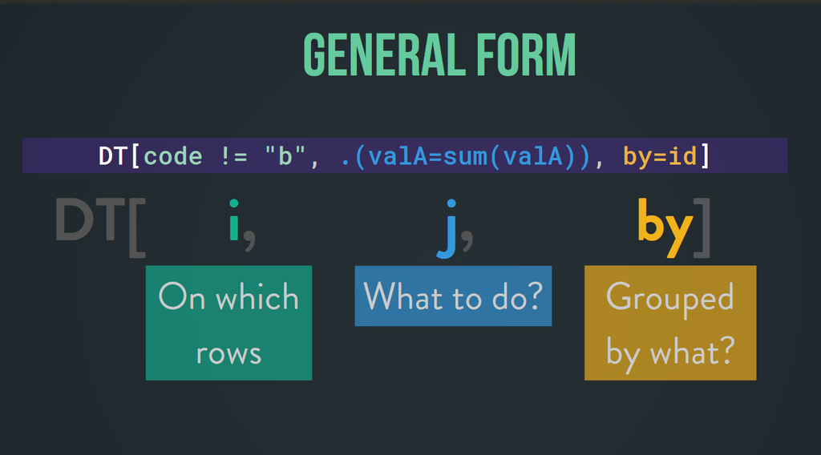

## How to obtain data.table?

**Import as data.table or convert existing formats to data.table**

1. Import data using function **fread()**.

**`dt_import <- fread("PATH/TO/FILE")`**

2. Convert data.frame (even other objects such as matrices, GRanges object…) using **as.data.table()**.

**`dt_import <- as.data.table(df)`**

3. Another approach of converting object to data.table using **setDT()** but without defining the new variable.

**`setDT(df)`**

**Tip**

A **file path** tells R where to find or save a file.

- **Absolute path**: The full location starting from the root of your computer.
  - Example: `"C:/Users/Paula/Documents/data.csv"`
- **Relative path**: A shortcut from the current working directory.
  - Example: `"data/data.csv"`

Use `getwd()` to check your current working directory.

💡 **Tip**: In RStudio Projects, use **relative paths** so your code works on any computer.

## From *data.frame* to *data.table*

Run the code chunk below. If you want, check it out using **rownames()**.

```r
( df_letters <- data.frame( one=1:6, two=2:7, row.names=letters[1:6]) )
```

|  | one | two |
| --- | --- | --- |
| a | 1 | 2 |
| b | 2 | 3 |
| c | 3 | 4 |
| d | 4 | 5 |
| e | 5 | 6 |
| f | 6 | 7 |

```r
( dt_letters <- as.data.table(df_letters) )
```

| one | two |
| --- | --- |
| 1 | 2 |
| 2 | 3 |
| 3 | 4 |
| 4 | 5 |
| 5 | 6 |
| 6 | 7 |

### How to keep the rownames?

Set argument *keep.rownames* to TRUE if you want to keep the rownames as a separate column in data.table.

```r
( dt_letters <- as.data.table(df_letters, keep.rownames=TRUE) )
```

| rn | one | two |
| --- | --- | --- |
| a | 1 | 2 |
| b | 2 | 3 |
| c | 3 | 4 |
| d | 4 | 5 |
| e | 5 | 6 |
| f | 6 | 7 |

Instead of keep.rownames=TRUE, you can specify the name of the column containing the rownames from the data.frame.

Example:

```r
( dt_letters <- as.data.table(df_letters, keep.rownames="letters") )
```

| letters | one | two |
| --- | --- | --- |
| a | 1 | 2 |
| b | 2 | 3 |
| c | 3 | 4 |
| d | 4 | 5 |
| e | 5 | 6 |
| f | 6 | 7 |

#### Task example: Convert *iris* to data table using as.data.table

Create a variable **iris_dt** that contains iris data set as data.table object. In this tutorial we are going to compare and analyze the default data set *iris* as data frame and data table objects.

```r
# Write solution here
```

## Row subsetting

### Syntax comparison

Operation

*data.frame*

[output not shown]

Subseting rows

`df[1:20, ]`

`df[1:20]`

Subseting rows based on criteria

`df[df$id < 4, ]`

`df[id < 4]`

##### Task

Select all rows in **iris_dt** with Sepal.Length less than 6.7 and Petal.Length less than 1.2.

```r
# Write the solution here
```

Select only setosa species with more than 0.3 Petal.Width.

```r
# Write the solution here
```

## Column subsetting

### Syntax comparison

Operation

*data.frame*

[output not shown]

Subseting columns

`df[, c(1,5)]`

`df[, c(1,5)]`

Subseting columns based on colnames

`df[, c("id")]`

`df[,.(id)]`

```r
iris_dt[, .(Species, Sepal.Width)]
```

| Species | Sepal.Width |
| --- | --- |
| setosa | 3.5 |
| setosa | 3.0 |
| setosa | 3.2 |
| setosa | 3.1 |
| setosa | 3.6 |
| setosa | 3.9 |
| setosa | 3.4 |
| setosa | 3.4 |
| setosa | 2.9 |
| setosa | 3.1 |

[output cut: 140 more lines]

**Important**

*Data.table* does not use **c()** but **.()** which represents list

Select columns Petal.Length and Petal.Width and first 3 rows

```r
# Write the solution here
```

### Additional methods of subsetting columns in data.table

**Tip**

1. **Using a character vector of column names**

You can store column names in a vector and use `..` to evaluate it inside `data.table`.

```r
cnames <- c("Petal.Length", "Petal.Width")

iris_dt[1:3, ..cnames]
```

| Petal.Length | Petal.Width |
| --- | --- |
| 1.4 | 0.2 |
| 1.4 | 0.2 |
| 1.3 | 0.2 |

2. **Using a range of column names**

You can select a range of columns using the `:` operator between two column names.

```r
iris_dt[1:3, Sepal.Length:Petal.Width]
```

| Sepal.Length | Sepal.Width | Petal.Length | Petal.Width |
| --- | --- | --- | --- |
| 5.1 | 3.5 | 1.4 | 0.2 |
| 4.9 | 3.0 | 1.4 | 0.2 |
| 4.7 | 3.2 | 1.3 | 0.2 |

3. **Negative subsetting to exclude columns**

Use `-()` or `!()` to exclude a range of columns.

```r
iris_dt[1:3, -(Sepal.Length:Petal.Width)]
```

| Species |
| --- |
| setosa |
| setosa |
| setosa |

```r
iris_dt[1:3, !(Sepal.Length:Petal.Length)]
```

| Petal.Width | Species |
| --- | --- |
| 0.2 | setosa |
| 0.2 | setosa |
| 0.2 | setosa |

Note: `Sepal.Length:Petal.Width` works only in column context—it is not the same as numeric indexing.

##### Task

Select all rows in **iris_dt** with Sepal.Width equal to **3.0**, but show only columns for **Species** and *Sepal.Width* (Do it by using column names!). You may also try other methods of subsetting.

```r
# Write the solution here
```

## Operation on columns

### Syntax comparison

| Operation | *data.frame* | *data.table* |
| --- | --- | --- |
| Calculate sum | `sum(df$id)` | `df[, sum(id)]` |
| Calculate sum by group | `by(df$id,` `df$group,` `sum)` | `df[, sum(id), by=group]` |
| Calling column out as a vector | `df$id` | `df[, id]` |

Calculate mean of Sepal.Width for all species.

```r
iris_dt[, mean(Sepal.Width)]
```

```
[1] 3.057333
```

Calculate mean of Sepal.Width for and for each species

```r
iris_dt[, mean(Sepal.Width), by=Species]
```

| Species | V1 |
| --- | --- |
| setosa | 3.428 |
| versicolor | 2.770 |
| virginica | 2.974 |

Also the following syntax works for data.table because in the third part it is always the group operation when calculating something per rows: `iris_dt[, mean(Sepal.Width), Species]`

**Adding the column immediately when performing the operation in data.table**

Syntax: `df[, .(new_col = sum(id) ), by=group]`

Example:

```r
iris_dt[, .( mean_col = mean(Sepal.Width) ), by=Species]
```

| Species | mean_col |
| --- | --- |
| setosa | 3.428 |
| versicolor | 2.770 |
| virginica | 2.974 |

### The power of *data.table* over *data.frame*

`data.table` offers an elegant and efficient way to perform multiple calculations on columns and save the results — all in a concise syntax.

[output not shown]

Output example

```r
iris_dt[ ,
        .(mean=mean(Sepal.Width),
          sd=sd(Sepal.Width),
          min_x= min(Sepal.Width),
          max_x= max(Sepal.Width)),
        by=Species][order(mean)]
```

| Species | mean | sd | min_x | max_x |
| --- | --- | --- | --- | --- |
| versicolor | 2.770 | 0.3137983 | 2.0 | 3.4 |
| virginica | 2.974 | 0.3224966 | 2.2 | 3.8 |
| setosa | 3.428 | 0.3790644 | 2.3 | 4.4 |

##### Task

Select all rows where Sepal.Length < 6.7 and flower species **virginica** and calculate mean Petal.Width in **iris_dt.** Do it with and without chaining.

*With chaining*

```r
# Write the solution here
```

*No chaining*

```r
# Write the solution here
```

### Adding new permanent columns

Adding one columns in data table is done with **:=** and multiple columns with **‘:=’**.

Here is a new column that contains the maximal sepal width for each species was added.

```r
iris_dt[, max_width1 := max(Sepal.Width), Species]
iris_dt[1:3]
```

| Sepal.Length | Sepal.Width | Petal.Length | Petal.Width | Species | max_width1 |
| --- | --- | --- | --- | --- | --- |
| 5.1 | 3.5 | 1.4 | 0.2 | setosa | 4.4 |
| 4.9 | 3.0 | 1.4 | 0.2 | setosa | 4.4 |
| 4.7 | 3.2 | 1.3 | 0.2 | setosa | 4.4 |

Addition of multiple columns.

```r
iris_dt[, ":=" (max_width2 = max(Sepal.Width),
                max_width3 = max(Sepal.Length) ),
        by=.(Species)]
iris_dt[1:3]
```

| Sepal.Length | Sepal.Width | Petal.Length | Petal.Width | Species | max_width1 | max_width2 | max_width3 |
| --- | --- | --- | --- | --- | --- | --- | --- |
| 5.1 | 3.5 | 1.4 | 0.2 | setosa | 4.4 | 4.4 | 5.8 |
| 4.9 | 3.0 | 1.4 | 0.2 | setosa | 4.4 | 4.4 | 5.8 |
| 4.7 | 3.2 | 1.3 | 0.2 | setosa | 4.4 | 4.4 | 5.8 |

##### Task: Add a new column

Add columns to iris_dt that represent mean and sd of `Petal.Width` grouped by species. Columns are called **meanPW** and **sdPW**.

```r
# Write the solution here
```

Use function **uniqueN()** to check how many unique mean `Petal.Width` there are in total and by Species group.

```r
# Write the solution here
```

### Special symbols in data.table

**.N** (an integer containing the number of rows in the group)

```r
iris_dt[, .N]
```

```
[1] 150
```

Can be used on groups. What is happening here with this subsetting in group?

```r
iris_dt[, .N, by=.(Species, Sepal.Length>=4.8)]
```

| Species | Sepal.Length | N |
| --- | --- | --- |
| setosa | TRUE | 39 |
| setosa | FALSE | 11 |
| versicolor | TRUE | 50 |
| virginica | TRUE | 50 |

##### Task: :=, .N

Add columns to **iris_dt** that represent number of observations of all rows for which Petal.Length is smaller than 6.5 in **iris_dt** grouped by species.

```r
# Write the solution here
```

Moreover, show only the newly added columns in your final results and use `na.omit()` to remove all missing values from your table

```r
# Write the solution here
```

One great benefit of data.table is the ability to **sub-assign by reference**: Try it: select all rows that have species==“virginica” and rename those Species entries using `:=` to `new_virginica`.

```r
# Write the solution here
```

## Subset of the original Data.table

**.SD** (a smaller data.table that is a **Subset** of the original **Data.table** for each group)

**.SDcols** (subset columns which are then used by .SD)

- Select all columns with .SD. Select only a subset of all columns by .SDcols

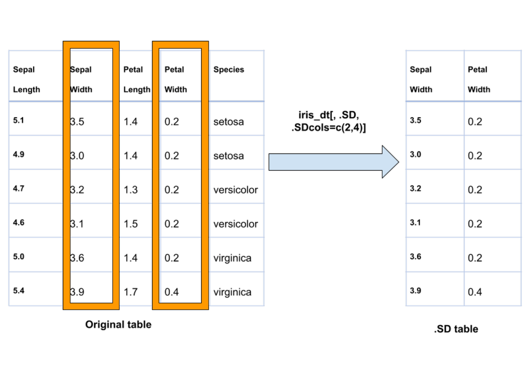

Selecting columns can be done by writing column names in .SDcols (Note: It is important to write it as stings in *c()* )

```r
iris_dt[, .SD, .SDcols=c("Sepal.Width", "Species")][1:2]
```

| Sepal.Width | Species |
| --- | --- |
| 3.5 | setosa |
| 3.0 | setosa |

This allows powerful calculation on subset of desired columns and groups.

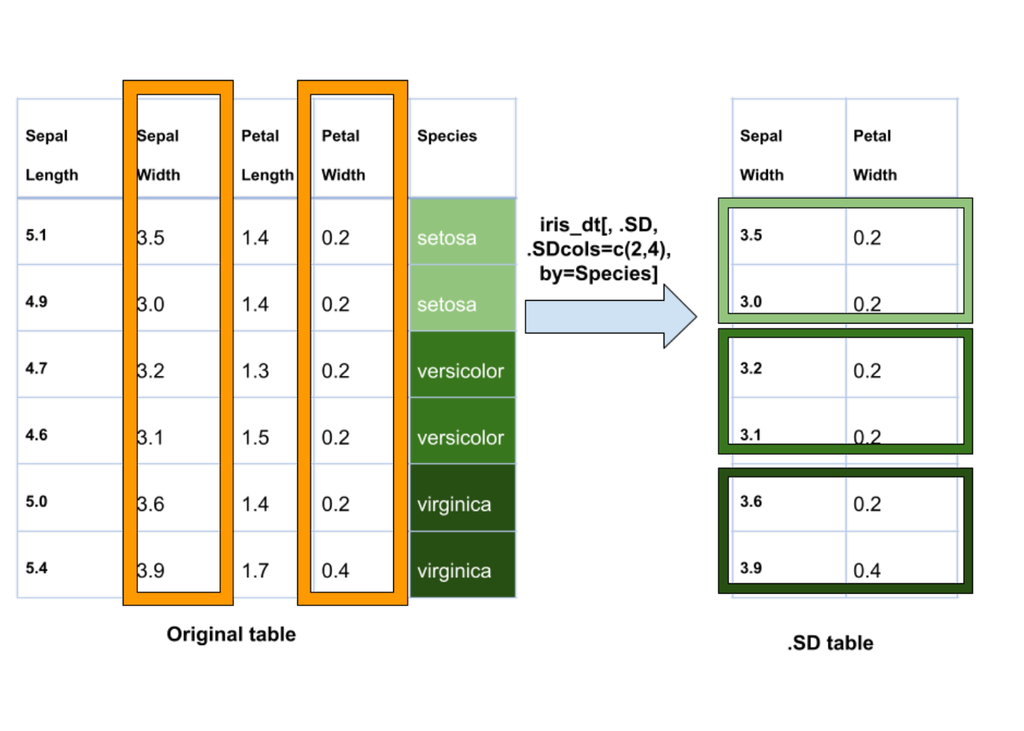

You can use `lapply()` together with `.SD` (Subset of Data) to apply functions to selected columns within groups. This is particularly useful for performing calculations like mean or sum on a subset of numeric columns.

```r
iris_dt[, lapply(.SD, mean), by=Species, .SDcols=1:2]
```

| Species | Sepal.Length | Sepal.Width |
| --- | --- | --- |
| setosa | 5.006 | 3.428 |
| versicolor | 5.936 | 2.770 |
| virginica | 6.588 | 2.974 |

Apply mean to all numeric columns by species

```r
iris_dt[, lapply(.SD, mean), by=Species, .SDcols=is.numeric]
```

| Species | Sepal.Length | Sepal.Width | Petal.Length | Petal.Width | max_width1 | max_width2 | max_width3 |
| --- | --- | --- | --- | --- | --- | --- | --- |
| setosa | 5.006 | 3.428 | 1.462 | 0.246 | 4.4 | 4.4 | 5.8 |
| versicolor | 5.936 | 2.770 | 4.260 | 1.326 | 3.4 | 3.4 | 7.0 |
| virginica | 6.588 | 2.974 | 5.552 | 2.026 | 3.8 | 3.8 | 7.9 |

.SD is amazing for selecting first and last row of certain group since we can imagine every group with selected table as a new separate data table. As well as other operation that can be done on *data.table*.

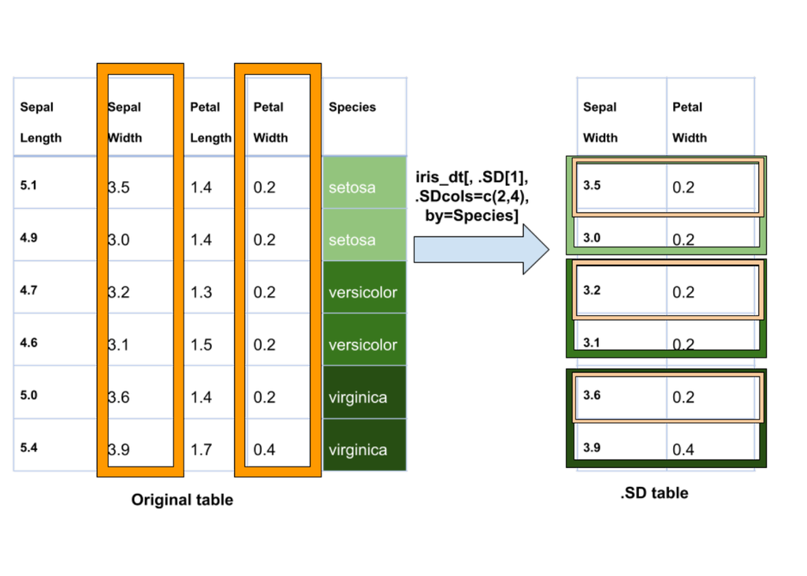

```r
iris_dt[, .SD[c(1, .N)], by=Species]
```

| Species | Sepal.Length | Sepal.Width | Petal.Length | Petal.Width | max_width1 | max_width2 | max_width3 |
| --- | --- | --- | --- | --- | --- | --- | --- |
| setosa | 5.1 | 3.5 | 1.4 | 0.2 | 4.4 | 4.4 | 5.8 |
| setosa | 5.0 | 3.3 | 1.4 | 0.2 | 4.4 | 4.4 | 5.8 |
| versicolor | 7.0 | 3.2 | 4.7 | 1.4 | 3.4 | 3.4 | 7.0 |
| versicolor | 5.7 | 2.8 | 4.1 | 1.3 | 3.4 | 3.4 | 7.0 |
| virginica | 6.3 | 3.3 | 6.0 | 2.5 | 3.8 | 3.8 | 7.9 |
| virginica | 5.9 | 3.0 | 5.1 | 1.8 | 3.8 | 3.8 | 7.9 |

##### Task: .SD

Order the results by Petal.Width and select first three (smallest) observations by species. Calculate mean of first three columns for iris_dt for those observations. Do it in one command with chaining.

```r
# Write the solution here
```

## Combining tables

### Binding tables

How to “stitch” two or more data objects into one?

```r
tb1 <- data.table(sampleID = c(6:1),
                  cancer = c("Breast","Breast","Brain","Liver","Brain","Pancreas"))
tb2 <- data.table(sampleID = c(7, 4, 6, 2, 8),
                  gender = c("F","F","M","F","M"))
head(tb1,3)
```

| sampleID | cancer |
| --- | --- |
| 6 | Breast |
| 5 | Breast |
| 4 | Brain |

```r
head(tb2,3)
```

| sampleID | gender |
| --- | --- |
| 7 | F |
| 4 | F |
| 6 | M |

Function **rbind()** binds the tables by rows. Try run the code below and see what happens. Why is that?

```r
rbind(tb1, tb2)
```

```
Error in rbindlist(l, use.names, fill, idcol, ignore.attr): Column 2 ['gender'] of item 2 is missing in item 1. Use fill=TRUE to fill with NA (NULL for list columns), or use.names=FALSE to ignore column names.
```

```r
rbind(tb1, tb2, fill=TRUE)
```

| sampleID | cancer | gender |
| --- | --- | --- |
| 6 | Breast | NA |
| 5 | Breast | NA |
| 4 | Brain | NA |
| 3 | Liver | NA |
| 2 | Brain | NA |
| 1 | Pancreas | NA |
| 7 | NA | F |
| 4 | NA | F |
| 6 | NA | M |
| 2 | NA | F |

[output cut: 1 more lines]

Function **cbind()** binds the tables. Do you notice anything strange when you run the code below?

```r
cbind(tb1, tb2)
```

| sampleID | cancer | sampleID | gender |
| --- | --- | --- | --- |
| 6 | Breast | 7 | F |
| 5 | Breast | 4 | F |
| 4 | Brain | 6 | M |
| 3 | Liver | 2 | F |
| 2 | Brain | 8 | M |
| 1 | Pancreas | 7 | F |

### `merge()`

[figure not shown]

Specify by which column you want to merge by and set the argument **all=** to TRUE to perform the full join

```r
merge(tb1, tb2, by="sampleID") #if setkey was used prior then merge(tb1,tb2) works the same
```

| sampleID | cancer | gender |
| --- | --- | --- |
| 2 | Brain | F |
| 4 | Brain | F |
| 6 | Breast | M |

```r
merge(tb1, tb2, by="sampleID", all=TRUE)
```

| sampleID | cancer | gender |
| --- | --- | --- |
| 1 | Pancreas | NA |
| 2 | Brain | F |
| 3 | Liver | NA |
| 4 | Brain | F |
| 5 | Breast | NA |
| 6 | Breast | M |
| 7 | NA | F |
| 8 | NA | M |

Right and left join

```r
merge(tb1, tb2, by="sampleID", all.x = TRUE)
```

| sampleID | cancer | gender |
| --- | --- | --- |
| 1 | Pancreas | NA |
| 2 | Brain | F |
| 3 | Liver | NA |
| 4 | Brain | F |
| 5 | Breast | NA |
| 6 | Breast | M |

```r
merge(tb1, tb2, by="sampleID", all.y = TRUE)
```

| sampleID | cancer | gender |
| --- | --- | --- |
| 2 | Brain | F |
| 4 | Brain | F |
| 6 | Breast | M |
| 7 | NA | F |
| 8 | NA | M |

## Tidying the table

Tidying a data table often includes renaming columns to make them more informative or consistent.

**Tip**

You can rename columns using `names()` or `colnames()`.

`names(dt_cancer) <- vec_names`

```r
dt_cancer <- merge(tb1, tb2, by="sampleID", all=TRUE)
dt_cancer
```

| sampleID | cancer | gender |
| --- | --- | --- |
| 1 | Pancreas | NA |
| 2 | Brain | F |
| 3 | Liver | NA |
| 4 | Brain | F |
| 5 | Breast | NA |
| 6 | Breast | M |
| 7 | NA | F |
| 8 | NA | M |

```r
names(dt_cancer)[1] <- "id"
dt_cancer
```

| id | cancer | gender |
| --- | --- | --- |
| 1 | Pancreas | NA |
| 2 | Brain | F |
| 3 | Liver | NA |
| 4 | Brain | F |
| 5 | Breast | NA |
| 6 | Breast | M |
| 7 | NA | F |
| 8 | NA | M |

**Tip**

You can rename columns using data.table: `setnames`

`setnames(dt_cancer, "old_names", "new_names")`

```r
names(dt_cancer)
```

```
[1] "id"     "cancer" "gender"
```

```r
setnames(dt_cancer,  "id", "sampleID")
names(dt_cancer)
```

```
[1] "sampleID" "cancer"   "gender"
```

### Ordering columns

Subseting

`dt[,.(col3, col10, col2)]`

```r
dt_cancer[,.(gender, sampleID)]
```

| gender | sampleID |
| --- | --- |
| NA | 1 |
| F | 2 |
| NA | 3 |
| F | 4 |
| NA | 5 |
| M | 6 |
| F | 7 |
| M | 8 |

data.table: setcolorder()

`setcolorder(dt_cancer, neworder)`

```r
dt_cancer
```

| sampleID | cancer | gender |
| --- | --- | --- |
| 1 | Pancreas | NA |
| 2 | Brain | F |
| 3 | Liver | NA |
| 4 | Brain | F |
| 5 | Breast | NA |
| 6 | Breast | M |
| 7 | NA | F |
| 8 | NA | M |

```r
setcolorder(dt_cancer, c("gender","sampleID"))
dt_cancer
```

| gender | sampleID | cancer |
| --- | --- | --- |
| NA | 1 | Pancreas |
| F | 2 | Brain |
| NA | 3 | Liver |
| F | 4 | Brain |
| NA | 5 | Breast |
| M | 6 | Breast |
| F | 7 | NA |
| M | 8 | NA |

## Reshaping the table

You can create a modified version of an existing `data.table` by using `copy()` to avoid changing the original data. Then, use `:=` to add or modify columns by reference.

In the example below, we create two new columns (`BRCA2` and `ATM`) filled with random values between 40 and 6000 for 6 rows:

```r
tb.shape <- copy(tb1)
tb.shape[, ":=" (
            BRCA2=sample(40:6000,6),
            ATM=sample(40:6000,6)) ]

tb.shape
```

| sampleID | cancer | BRCA2 | ATM |
| --- | --- | --- | --- |
| 6 | Breast | 707 | 4148 |
| 5 | Breast | 1976 | 5609 |
| 4 | Brain | 5568 | 3376 |
| 3 | Liver | 257 | 5132 |
| 2 | Brain | 5964 | 4826 |
| 1 | Pancreas | 214 | 2351 |

**`melt (wide to long)`**

```r
melt(tb.shape, id.vars = c("sampleID", "cancer"),
                measure.vars = c("BRCA2", "ATM"))
```

| sampleID | cancer | variable | value |
| --- | --- | --- | --- |
| 6 | Breast | BRCA2 | 707 |
| 5 | Breast | BRCA2 | 1976 |
| 4 | Brain | BRCA2 | 5568 |
| 3 | Liver | BRCA2 | 257 |
| 2 | Brain | BRCA2 | 5964 |
| 1 | Pancreas | BRCA2 | 214 |
| 6 | Breast | ATM | 4148 |
| 5 | Breast | ATM | 5609 |
| 4 | Brain | ATM | 3376 |
| 3 | Liver | ATM | 5132 |

[output cut: 2 more lines]

```r
(tb1.m1  <- melt(tb.shape,
                 measure.vars = c("BRCA2", "ATM"),
                 variable.name = "genes",
                 value.name = "n_mutations")
 )
```

| sampleID | cancer | genes | n_mutations |
| --- | --- | --- | --- |
| 6 | Breast | BRCA2 | 707 |
| 5 | Breast | BRCA2 | 1976 |
| 4 | Brain | BRCA2 | 5568 |
| 3 | Liver | BRCA2 | 257 |
| 2 | Brain | BRCA2 | 5964 |
| 1 | Pancreas | BRCA2 | 214 |
| 6 | Breast | ATM | 4148 |
| 5 | Breast | ATM | 5609 |
| 4 | Brain | ATM | 3376 |
| 3 | Liver | ATM | 5132 |

[output cut: 2 more lines]

**`dcast (long to wide)`**

We want to get the original table from the previous reshaped one using **dcast()**

```r
dcast(tb1.m1, sampleID + cancer ~ genes, value.var = "n_mutations")
```

| sampleID | cancer | BRCA2 | ATM |
| --- | --- | --- | --- |
| 1 | Pancreas | 214 | 2351 |
| 2 | Brain | 5964 | 4826 |
| 3 | Liver | 257 | 5132 |
| 4 | Brain | 5568 | 3376 |
| 5 | Breast | 1976 | 5609 |
| 6 | Breast | 707 | 4148 |

## Saving a table with `fwrite()`

The `fwrite()` function from the `data.table` package is a fast and efficient way to write data tables to disk.

**Tip**

fwrite(dt, file = “results/iris_summary.csv”)